# Anxiety symptoms

# 1 Description of DataSchema variable

- Short name: `anxiety_symp`
- Variable label: `Psychological measure of anxiety symptoms`
- Domain: `Psycological measures`
- Value type: `categorical`
- Category coding:
- Comments: `In this template we will collect any anxiety symptom taking individual questions about worry, trembling, anxiety distress or severity, anxiety in general, other body features or scale items that correspond to these anxiety symptoms. In this sense, here we include a broad definition of anxiety symptoms. On a different variable we will have a more strict definition that will collect "anxiety diagnosis" following consensus criteria of strudies or scale manuals. However, only 5 studies include validated scales as such and most of them are different and some of them do not mention cut-off points, are ambiguous about them, or have different criteria depending on their population.`

| **Code** | **Category Label** |
| --- | --- |
| 0 | no anxiety symptoms |
| 1 | presence of anxiety |

- Category missings:

| **Code** | **Category Label** |
| --- | --- |
| 991 | CAPI/interviewer error |
| 992 | Impute |
| 993 | Disable to measure |
| 994 | Not attempt/not done |
| 995 | Does not answer |
| 996 | Not applicable |
| 997 | Refuse |
| 998 | Do not know |
| 999 | Missing |

# 2 Data process

## 2.1 England

### 2.1.1 Wave 1

There is no variable.

### 2.1.2 Wave 2

There is no variable.

### 2.1.3 Wave 3

#### 2.1.3.1 Study-specific variable description

| **Name** | `hepsyan` |
| --- | --- |
| **Label** | `Psychiatric problem has: anxiety` |
| **Table name** | `wave_3_elsa_data_v4` |
| **Categories** | `0 = Not mentioned` |
|  | `1 = Mentioned` |
| **Missings** | `-9 = Refusal` |
|  | `-8 = Don't know` |
|  | `-2 = Schedule not applicable` |
|  | `-1 = Not applicable` |
| **Description** |  |

Anxiety symptoms

| Sample size | Missing values |
| --- | --- |
| 9771 | 9005 |

Category

|  | 0 | 1 |
| --- | --- | --- |
| Frequency | 347.00 | 419.00 |
| Percentage | 3.55 | 4.29 |

Type of missing

|  | -9 | -8 | -2 | -1 | NA |
| --- | --- | --- | --- | --- | --- |
| Frequency | 0 | 0 | 0 | 9005.00 | 0 |
| Percentage | 0 | 0 | 0 | 92.16 | 0 |

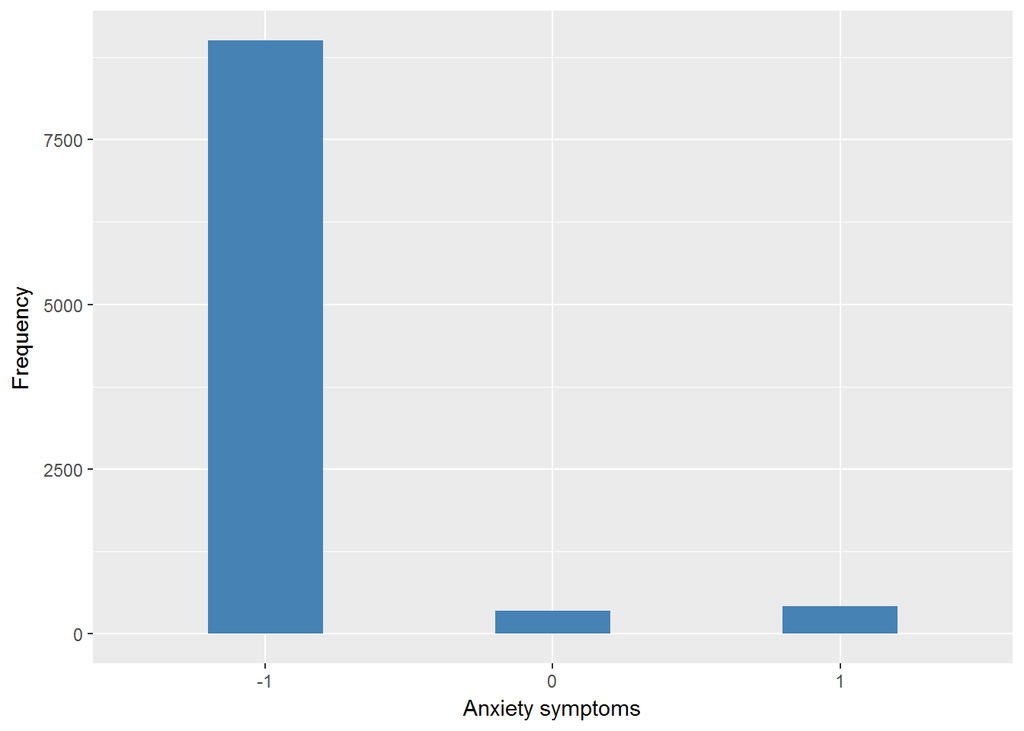

#### 2.1.3.2 Harmonisation algorithm

The harmonized variable is the same than the study-specific variable but the missing values have to be recoded as follows:

- `recode -9 "Refusal" into 997`
- `recode -8 "Don't know" into 998`
- `recode -2 "Schedule not applicable" into 0`
- `recode -1 "Not applicable" into 0`
- `NA into 999`

**R script:**

```r
ELSA_ds_w3 <- tibble(id = ELSA_as$id)
ELSA_ds_w3$anxiety_symp <- car::recode(ELSA_as[[2]], "-9=997; -8=998; -2=0; -1=0; NA=999")
ELSA_ds_w3$anxiety_symp <- labelled(ELSA_ds_w3$anxiety_symp, labels = c(`no anxiety symptoms` = 0,
    `presence of anxiety` = 1, Missing = 999, `Do not know` = 998, Refuse = 997,
    `Not applicable` = 996, `Does not answer` = 995, `Not attempt not done` = 994,
    `Disable to measure` = 993, Impute = 992, `CAPI interviewer error` = 991))
```

#### 2.1.3.3 Statistical description of the new harmonised variable

Anxiety symptoms

| Sample size | Missing values |
| --- | --- |
| 9771 | 0 |

Category

|  | 0 | 1 |
| --- | --- | --- |
| Frequency | 9352.00 | 419.00 |
| Percentage | 95.71 | 4.29 |

Type of missing

|  | 991 | 992 | 993 | 994 | 995 | 996 | 997 | 998 | 999 | NA |
| --- | --- | --- | --- | --- | --- | --- | --- | --- | --- | --- |
| Frequency | 0 | 0 | 0 | 0 | 0 | 0 | 0 | 0 | 0 | 0 |
| Percentage | 0 | 0 | 0 | 0 | 0 | 0 | 0 | 0 | 0 | 0 |

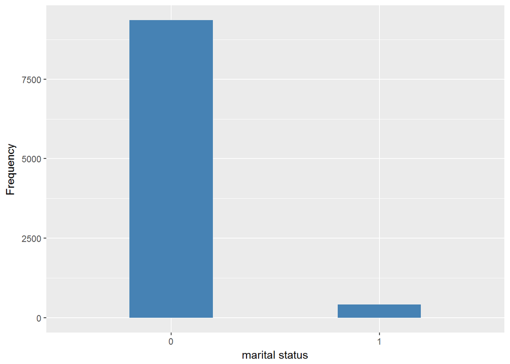

#### 2.1.3.4 Validation

|  | (0,-1,-2)->0 | 1 |
| --- | --- | --- |
| BeforeH | 9352 | 419 |
| AfterH | 9352 | 419 |

### 2.1.4 Wave 4

#### 2.1.4.1 Study-specific variable description

| **Name** | `hepsyan` |
| --- | --- |
| **Label** | `Psychiatric problem has: anxiety` |
| **Table name** | `wave_4_elsa_data_v3` |
| **Categories** | `0 = Not mentioned` |
|  | `1 = Mentioned` |
| **Missings** | `-9 = Refusal` |
|  | `-8 = Don't know` |
|  | `-2 = Capi/Interview Error` |
|  | `-1 = Not applicable` |
| **Description** |  |

Anxiety symptoms

| Sample size | Missing values |
| --- | --- |
| 11050 | 10095 |

Category

|  | 0 | 1 |
| --- | --- | --- |
| Frequency | 420.0 | 535.00 |
| Percentage | 3.8 | 4.84 |

Type of missing

|  | -9 | -8 | -2 | -1 | NA |
| --- | --- | --- | --- | --- | --- |
| Frequency | 0 | 2.00 | 72.00 | 10021.00 | 0 |
| Percentage | 0 | 0.02 | 0.65 | 90.69 | 0 |

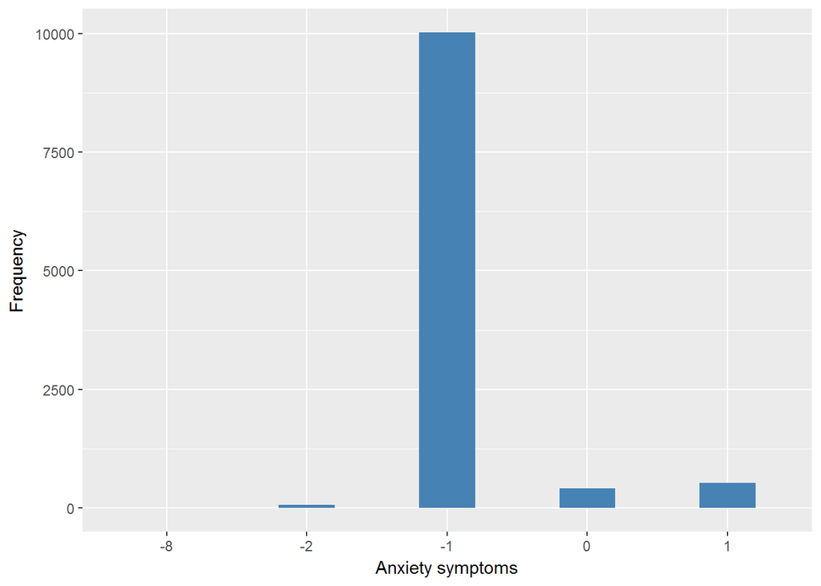

#### 2.1.4.2 Harmonisation algorithm

The harmonized variable is the same than the study-specific variable but the missing values have to be recoded as follows:

- `recode -9 "Refusal" into 997`
- `recode -8 "Don't know" into 998`
- `recode -2 "Capi/Interview Error" into 991`
- `recode -1 "Not applicable" into 0`
- `NA into 999`

**R script:**

```r
ELSA_ds_w4 <- tibble(id = ELSA_as$id)
ELSA_ds_w4$anxiety_symp <- car::recode(ELSA_as[[2]], "-9=997; -8=998; -2=991; -1=0; NA=999")
ELSA_ds_w4$anxiety_symp <- labelled(ELSA_ds_w4$anxiety_symp, labels = c(`no anxiety symptoms` = 0,
    `presence of anxiety` = 1, Missing = 999, `Do not know` = 998, Refuse = 997,
    `Not applicable` = 996, `Does not answer` = 995, `Not attempt not done` = 994,
    `Disable to measure` = 993, Impute = 992, `CAPI interviewer error` = 991))
```

#### 2.1.4.3 Statistical description of the new harmonised variable

Anxiety symptoms

| Sample size | Missing values |
| --- | --- |
| 11050 | 74 |

Category

|  | 0 | 1 |
| --- | --- | --- |
| Frequency | 10441.00 | 535.00 |
| Percentage | 94.49 | 4.84 |

Type of missing

|  | 991 | 992 | 993 | 994 | 995 | 996 | 997 | 998 | 999 | NA |
| --- | --- | --- | --- | --- | --- | --- | --- | --- | --- | --- |
| Frequency | 72.00 | 0 | 0 | 0 | 0 | 0 | 0 | 2.00 | 0 | 0 |
| Percentage | 0.65 | 0 | 0 | 0 | 0 | 0 | 0 | 0.02 | 0 | 0 |

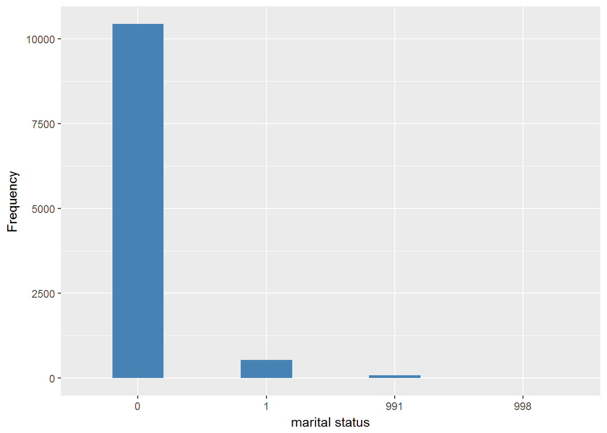

#### 2.1.4.4 Validation

|  | (0,-1)->0 | 1 | -2->991 | -8->998 |
| --- | --- | --- | --- | --- |
| BeforeH | 10441 | 535 | 72 | 2 |
| AfterH | 10441 | 535 | 72 | 2 |

### 2.1.5 Wave 5

#### 2.1.5.1 Study-specific variable description

| **Name** | `hepsyan` |
| --- | --- |
| **Label** | `Psychiatric problem has: anxiety` |
| **Table name** | `wave_5_elsa_data_v4` |
| **Categories** | `0 = Not mentioned` |
|  | `1 = Mentioned` |
| **Missings** | `-9 = Refusal` |
|  | `-8 = Don't know` |
|  | `-2 = Schedule not applicable` |
|  | `-1 = Item not applicable` |
| **Description** |  |

Anxiety symptoms

| Sample size | Missing values |
| --- | --- |
| 10274 | 9285 |

Category

|  | 0 | 1 |
| --- | --- | --- |
| Frequency | 443.00 | 546.00 |
| Percentage | 4.31 | 5.31 |

Type of missing

|  | -9 | -8 | -2 | -1 | NA |
| --- | --- | --- | --- | --- | --- |
| Frequency | 1.00 | 8.00 | 0 | 9276.00 | 0 |
| Percentage | 0.01 | 0.08 | 0 | 90.29 | 0 |

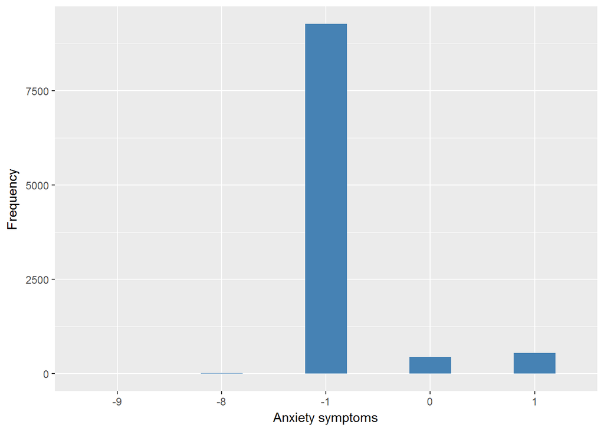

#### 2.1.5.2 Harmonisation algorithm

The harmonized variable is the same than the study-specific variable but the missing values have to be recoded as follows:

- `recode -9 "Refusal" into 997`
- `recode -8 "Don't know" into 998`
- `recode -2 "Schedule not applicable" into 0`
- `recode -1 "Not applicable" into 0`
- `NA into 999`

**R script:**

```r
ELSA_ds_w5 <- tibble(id = ELSA_as$id)
ELSA_ds_w5$anxiety_symp <- car::recode(ELSA_as[[2]], "-9=997; -8=998; -2=0; -1=0; NA=999")
ELSA_ds_w5$anxiety_symp <- labelled(ELSA_ds_w5$anxiety_symp, labels = c(`no anxiety symptoms` = 0,
    `presence of anxiety` = 1, Missing = 999, `Do not know` = 998, Refuse = 997,
    `Not applicable` = 996, `Does not answer` = 995, `Not attempt not done` = 994,
    `Disable to measure` = 993, Impute = 992, `CAPI interviewer error` = 991))
```

#### 2.1.5.3 Statistical description of the new harmonised variable

Anxiety symptoms

| Sample size | Missing values |
| --- | --- |
| 10274 | 9 |

Category

|  | 0 | 1 |
| --- | --- | --- |
| Frequency | 9719.0 | 546.00 |
| Percentage | 94.6 | 5.31 |

Type of missing

|  | 991 | 992 | 993 | 994 | 995 | 996 | 997 | 998 | 999 | NA |
| --- | --- | --- | --- | --- | --- | --- | --- | --- | --- | --- |
| Frequency | 0 | 0 | 0 | 0 | 0 | 0 | 1.00 | 8.00 | 0 | 0 |
| Percentage | 0 | 0 | 0 | 0 | 0 | 0 | 0.01 | 0.08 | 0 | 0 |

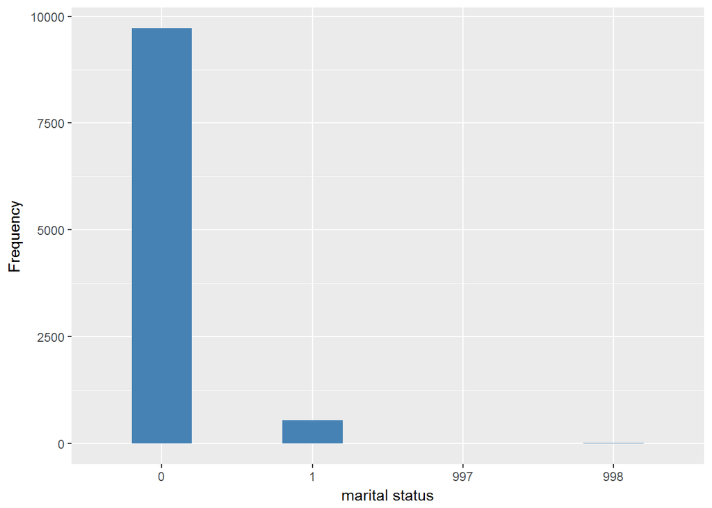

#### 2.1.5.4 Validation

|  | (0,-1,-2)->0 | 1 | -9->997 | -8->998 |
| --- | --- | --- | --- | --- |
| BeforeH | 9719 | 546 | 1 | 8 |
| AfterH | 9719 | 546 | 1 | 8 |

### 2.1.6 Wave 6

#### 2.1.6.1 Study-specific variable description

| **Name** | `hepsyan` |
| --- | --- |
| **Label** | `Psychiatric problem has: anxiety` |
| **Table name** | `wave_6_elsa_data_v2` |
| **Categories** | `0 = Not mentioned` |
|  | `1 = Mentioned` |
| **Missings** | `-9 = Refusal` |
|  | `-8 = Don't know` |
|  | `-2 = Schedule not applicable` |
|  | `-1 = Not applicable` |
| **Description** |  |

Anxiety symptoms

| Sample size | Missing values |
| --- | --- |
| 10601 | 9504 |

Category

|  | 0 | 1 |
| --- | --- | --- |
| Frequency | 510.00 | 587.00 |
| Percentage | 4.81 | 5.54 |

Type of missing

|  | -9 | -8 | -2 | -1 | NA |
| --- | --- | --- | --- | --- | --- |
| Frequency | 1.00 | 17.00 | 0 | 9486.00 | 0 |
| Percentage | 0.01 | 0.16 | 0 | 89.48 | 0 |

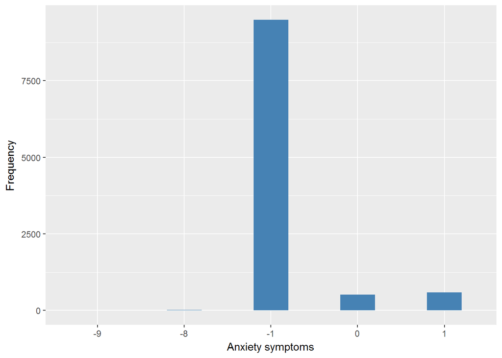

#### 2.1.6.2 Harmonisation algorithm

The harmonized variable is the same than the study-specific variable but the missing values have to be recoded as follows:

- `recode -9 "Refusal" into 997`
- `recode -8 "Don't know" into 998`
- `recode -2 "Schedule not applicable" into 0`
- `recode -1 "Not applicable" into 0`
- `NA into 999`

**R script:**

```r
ELSA_ds_w6 <- tibble(id = ELSA_as$id)
ELSA_ds_w6$anxiety_symp <- car::recode(ELSA_as[[2]], "-9=997; -8=998; -2=0; -1=0; NA=999")
ELSA_ds_w6$anxiety_symp <- labelled(ELSA_ds_w6$anxiety_symp, labels = c(`no anxiety symptoms` = 0,
    `presence of anxiety` = 1, Missing = 999, `Do not know` = 998, Refuse = 997,
    `Not applicable` = 996, `Does not answer` = 995, `Not attempt not done` = 994,
    `Disable to measure` = 993, Impute = 992, `CAPI interviewer error` = 991))
```

#### 2.1.6.3 Statistical description of the new harmonised variable

Anxiety symptoms

| Sample size | Missing values |
| --- | --- |
| 10601 | 18 |

Category

|  | 0 | 1 |
| --- | --- | --- |
| Frequency | 9996.00 | 587.00 |
| Percentage | 94.29 | 5.54 |

Type of missing

|  | 991 | 992 | 993 | 994 | 995 | 996 | 997 | 998 | 999 | NA |
| --- | --- | --- | --- | --- | --- | --- | --- | --- | --- | --- |
| Frequency | 0 | 0 | 0 | 0 | 0 | 0 | 1.00 | 17.00 | 0 | 0 |
| Percentage | 0 | 0 | 0 | 0 | 0 | 0 | 0.01 | 0.16 | 0 | 0 |

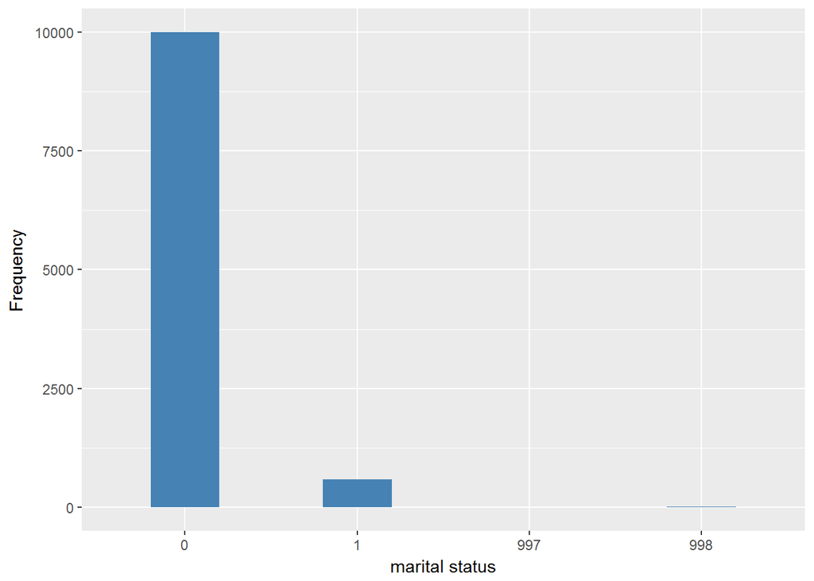

#### 2.1.6.4 Validation

|  | (0,-1,-2)->0 | 1 | -9->997 | -8->998 |
| --- | --- | --- | --- | --- |
| BeforeH | 9996 | 587 | 1 | 17 |
| AfterH | 9996 | 587 | 1 | 17 |

### 2.1.7 Wave 7

#### 2.1.7.1 Study-specific variable description

| **Name** | `hepsyan` |
| --- | --- |
| **Label** | `Psychiatric problem has: anxiety` |
| **Table name** | `wave_7_elsa_data` |
| **Categories** | `0 = Not mentioned` |
|  | `1 = Mentioned` |
| **Missings** | `-9 = Refusal` |
|  | `-8 = Don't know` |
|  | `-2 = Schedule not applicable` |
|  | `-1 = Not applicable` |
| **Description** |  |

Anxiety symptoms

| Sample size | Missing values |
| --- | --- |
| 9666 | 8655 |

Category

|  | 0 | 1 |
| --- | --- | --- |
| Frequency | 490.00 | 521.00 |
| Percentage | 5.07 | 5.39 |

Type of missing

|  | -9 | -8 | -2 | -1 | NA |
| --- | --- | --- | --- | --- | --- |
| Frequency | 6.00 | 22.00 | 0 | 8627.00 | 0 |
| Percentage | 0.06 | 0.23 | 0 | 89.25 | 0 |

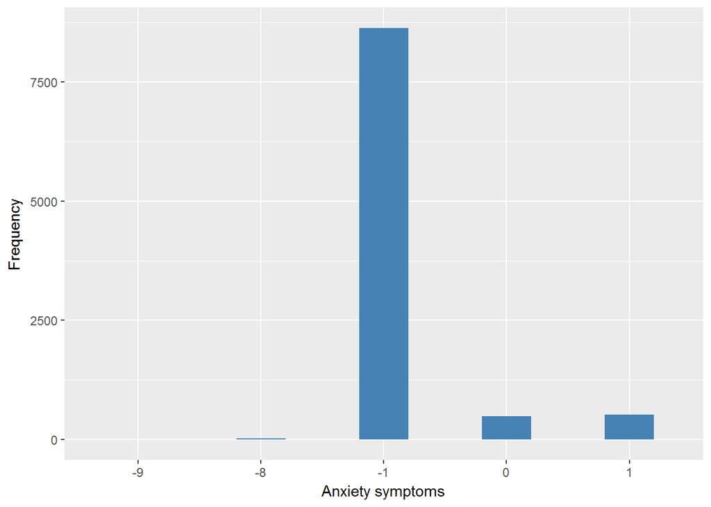

#### 2.1.7.2 Harmonisation algorithm

The harmonized variable is the same than the study-specific variable but the missing values have to be recoded as follows:

- `recode -9 "Refusal" into 997`
- `recode -8 "Don't know" into 998`
- `recode -2 "Schedule not applicable" into 0`
- `recode -1 "Not applicable" into 0`
- `NA into 999`

**R script:**

```r
ELSA_ds_w7 <- tibble(id = ELSA_as$id)
ELSA_ds_w7$anxiety_symp <- car::recode(ELSA_as[[2]], "-9=997; -8=998; -2=0; -1=0; NA=999")
ELSA_ds_w7$anxiety_symp <- labelled(ELSA_ds_w7$anxiety_symp, labels = c(`no anxiety symptoms` = 0,
    `presence of anxiety` = 1, Missing = 999, `Do not know` = 998, Refuse = 997,
    `Not applicable` = 996, `Does not answer` = 995, `Not attempt not done` = 994,
    `Disable to measure` = 993, Impute = 992, `CAPI interviewer error` = 991))
```

#### 2.1.7.3 Statistical description of the new harmonised variable

Anxiety symptoms

| Sample size | Missing values |
| --- | --- |
| 9666 | 28 |

Category

|  | 0 | 1 |
| --- | --- | --- |
| Frequency | 9117.00 | 521.00 |
| Percentage | 94.32 | 5.39 |

Type of missing

|  | 991 | 992 | 993 | 994 | 995 | 996 | 997 | 998 | 999 | NA |
| --- | --- | --- | --- | --- | --- | --- | --- | --- | --- | --- |
| Frequency | 0 | 0 | 0 | 0 | 0 | 0 | 6.00 | 22.00 | 0 | 0 |
| Percentage | 0 | 0 | 0 | 0 | 0 | 0 | 0.06 | 0.23 | 0 | 0 |

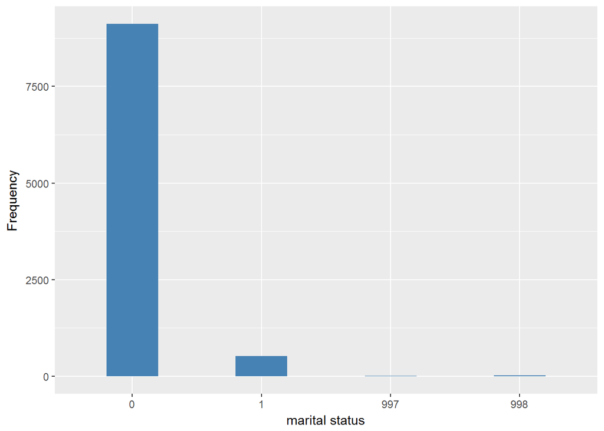

#### 2.1.7.4 Validation

|  | (0,-1,-2)->0 | 1 | -9->997 | -8->998 |
| --- | --- | --- | --- | --- |
| BeforeH | 9117 | 521 | 6 | 22 |
| AfterH | 9117 | 521 | 6 | 22 |

# 3 Quality estimation